# Atelier pratique avec Rmarkdown

## Exemple simple : rmd en pdf

[figure not shown]

[interactive chart not shown]

## Rmarkdown avec Rstudio

## Prise en main facile avec RStudio

Menu `File > New File > R Markdown...`

[figure not shown]

## Enregistrer le fichier .rmd crée

[figure not shown]

## Compiler (*knit*) un Rmarkdown

[figure not shown]

## Fichier généré (exemple HTML)

[interactive chart not shown]

## Comment cela fonctionne ?

## 🧶 Tricot d’un Rmarkdown ?

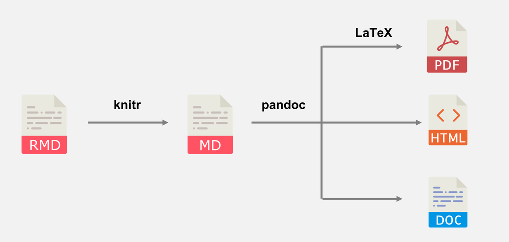

Pandoc est généralement pré-installé sur les systèmes d’exploitation MACOS et Windows.  
Si vous n’avez pas \(\LaTeX\) d’installé, utilisez le package [`tinytex`](https://cran.r-project.org/package=tinytex) pour la compilation en pdf.

## Les 3 composants d’un rmd

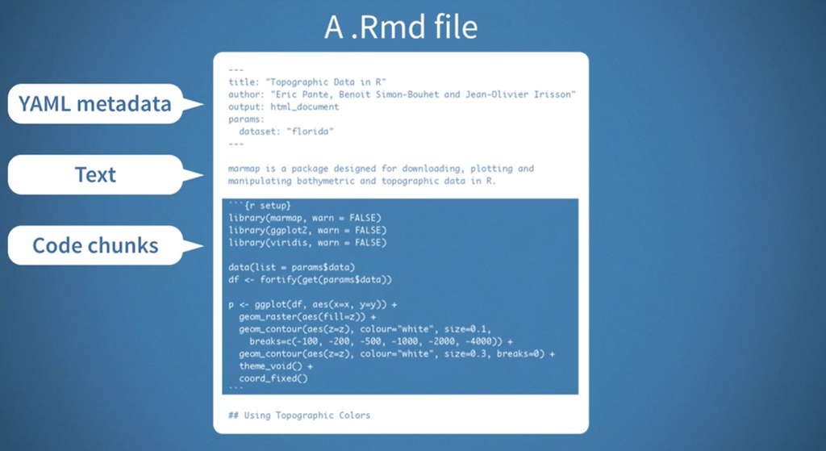

## Les 3 composants d’un rmd

- **En-tête `YAML`** : indications de variables pour la compilation du document : métadonnées (titre, auteur, date…), type de document souhaité (format et template), options de mise en page (TOC, Bibliographie, CSS…).  
  Documentation → [*R Markdown: The Definitive Guide*](https://bookdown.org/yihui/rmarkdown/html-document.html).
- **Texte balisé en `Markdown`** : texte en langage naturel mis forme grâce à la syntaxe markdown.  
  Documentation → [*Learn X in Y minutes*](https://learnxinyminutes.com/docs/markdown/)
- *Chunks* : code qui sera affiché (ou pas) et dont le résultat sera inséré (ou pas) dans le document final. Plusieurs options permettent de gérer l’éxécution, l’affichage du code et de résultats.  
  Documentation → [*Chunk options and package options*](https://yihui.org/knitr/options/)

## A. En-tête du document (`YAML`)

```yaml
---
title: Programmation lettrée et Notebook
author: Marc Done
date: 2023-02-21
output:
  ioslides_presentation:
    transition: slower
    incremental: true
    widescreen: true
    logo: img/rmarkdown.png
---
```

**De nombreuses variables sont paramétrables**. Certaines sont spécifiques à des formats de sortie ou à des templates. Mais, dans tous les cas :

**L’indentation des variables doit être parfaite !**

## Multiplier les formats de sortie ?

La variable `output` vous offre la possibilité de produire plusieurs formats à partir du même fichier Rmd :

```yaml
---
title: Programmation lettrée et Notebook
author: Marc Done
date: 2023-02-21
output:
  html_document: default
  pdf_document: default
---
```

*Kniter* votre fichier en ligne de commande de la façon suivante :

```r
rmarkdown::render("mon_premier_rmarkdown.Rmd", output_format = "all")
```

## Les *templates* disponibles

**De nombreux packages fournissent des modèles de mise en page prêts à l’emploi** :

`bookdown`, `distill`, `flexdashboard`, `hrbrthemes`, `komadown`, `komaletter`, `learnr`, `linl`, `memor`, `pagedown`, `papaja`, `pinp`, `prettydoc`, `radix`, `revealjs`, `rmarkdown`, `rmdformats`, `rmdshower`, `rticles`, `rzine`, `tufte`, `unilur`, `vitae`, `xaringan`…

Ils permettent de produire des documents de toute forme, comme :

- des documents (pages) HTML,  
- des documents paginés (articles, livres, thèses) en pdf avec \(\LaTeX\), docx, odt…,  
- des présentations/diaporama en format HTML, pdf ou pptx,  
- des tableaux de bord interactif,  
- des cours et sujets d’examens (interactif ou non),  
- et même des sites internet statiques !

## Ex : `rmdformats` - modèle `readthedown`

```yaml
---
title: "Template readthedown proposé par le package rmdformats"
date: "2023-02-21"
output:
  rmdformats::readthedown:
    highlight: kate
---
```

L’interface Rstudio permet de générer un rmd paramétré dans un modèle de mise en page souhaité. Pour cela, installer le package qui fournit le template que vous souhaitez utiliser. Ex :

```r
install.packages("rmdformats")
```

## Exemple `rmdformats`

Une fois installé, les templates proposés par le package installés sont disponibles en clic-buton dans Rstudio :

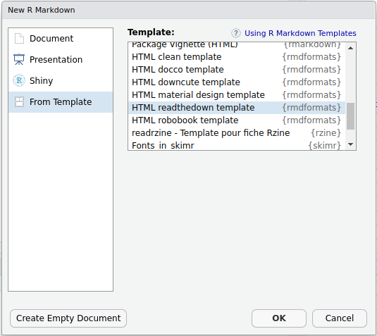

## Ajouter ses variables… modulables !

Pour produire des rapports sur différentes périodes, zones géographiques… A partir du même fichier R Markdown !

```yaml
---
title: Rapport statistique IDH
output: html_document
params:
  annee: 2023
  region: Europe
---
```

*Kniter* votre fichier en ligne de commande de la façon suivante :

```r
rmarkdown::render("monfichier.Rmd", params = list(annee = 2013, region = Asie))
```

## Ajouter ses variables… modulables !

Cette fonctionnalité est aussi disponible en clic-bouton via l’interface Rstudio :

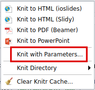

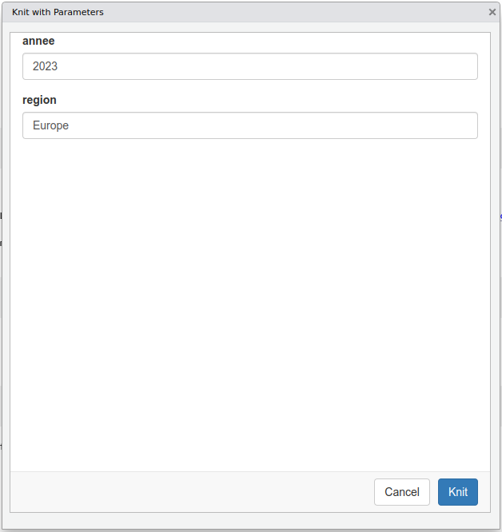

## B. Zone de texte - balisage `markdown`

[figure not shown]

https://www.markdownguide.org/

## C. Bloc de code - *chunks*

Deux façons d’insérer du code dans son document :

1. **Code chunk**

   ````r
   ```{r, eval=TRUE, echo=FALSE}

   head(mtcars)

   ```
   ````

2. **Inline code**, pour inclure du code dans une zone de texte

   ```markdown
   La moyenne est de `r mean(mtcars$cyl)`.
   ```

## Les [options disponibles](https://yihui.name/knitr/options/)

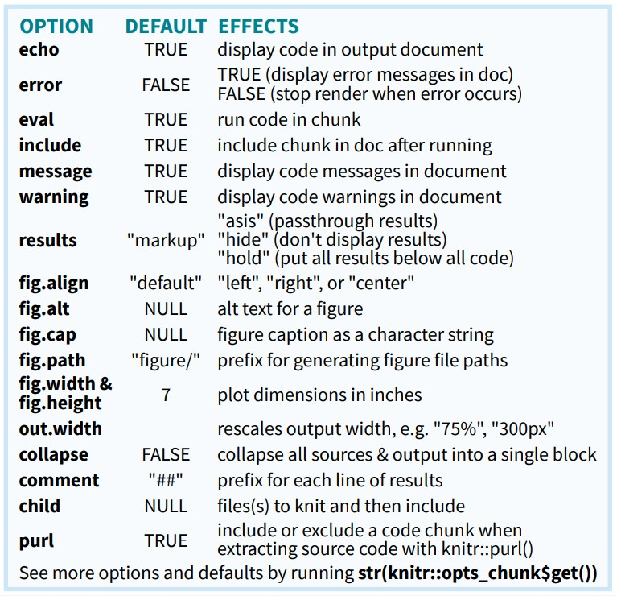

## *chunk* plurilingues

```r
names(knitr::knit_engines$get())
```

```
##  [1] "awk"       "bash"      "coffee"    "gawk"      "groovy"    "haskell"
##  [7] "lein"      "mysql"     "node"      "octave"    "perl"      "php"
## [13] "psql"      "Rscript"   "ruby"      "sas"       "scala"     "sed"
## [19] "sh"        "stata"     "zsh"       "asis"      "asy"       "block"
## [25] "block2"    "bslib"     "c"         "cat"       "cc"        "comment"
## [31] "css"       "ditaa"     "dot"       "embed"     "eviews"    "exec"
## [37] "fortran"   "fortran95" "go"        "highlight" "js"        "julia"
## [43] "python"    "R"         "Rcpp"      "sass"      "scss"      "sql"
## [49] "stan"      "targets"   "tikz"      "verbatim"  "glue"      "glue_sql"
## [55] "gluesql"
```

## Ex : `python` et le package `reticulate`

1. Initialisation de la configuration

   ````r
   ```{r, include = FALSE, eval = TRUE}
   library(reticulate)
   use_python("usr/local/bin/python")
   use_virtualenv("r-reticulate")
   py_install(c("pandas", "numpy"))
   ```
   ````

2. Script python

   ````python
   ```{python, eval = TRUE}
   a = 15 + 45
   print(a)
   ```
   ````

   ```
   ## 60
   ```

## Exemple : `SQL` avec scripts externes

**Etape 1 : connexion à la base de données**

````r
```{r , eval = TRUE}
conn <- DBI::dbConnect(RSQLite::SQLite(), path = ":memory:")
```
````

**Pour se déconnecter (en fin de document) :**

````r
```{r , eval = TRUE}
DBI::dbDisconnect(conn)
```
````

**Etape 2 : Lecture et éxécution d’un fichier sql**

````markdown
```{sql, connection=conn, code=readLines('sql/list_tables.sql')}

```
````

```sql
SELECT name FROM sqlite_master WHERE type='table';
```

1 records

| name |
| --- |
| mtcars |

## Ex : `node.js` avec un script externe

Vous voulez présenter du code `node.js`.  
Vos scripts sont dans des fichiers `.js`.

Vous pouvez écrire :

````markdown
```{node, code=readLines('node/example.js')}
```
````

```javascript
const hi = (name) => {
  console.log("Hello " + name + "!");
};

hi("Bob");
```

## Un peu de documentation ?

## Cheatsheet Rmarkdown

[R Markdown Cheat Sheet](https://posit.co/wp-content/uploads/2022/10/rmarkdown-1.pdf) par [RStudio](https://www.rstudio.com/), licence [CC BY 4.0](https://creativecommons.org/licenses/by/4.0/)

[interactive chart not shown]

## Bibliographie

**Les références :**

- Xie, Y., J.J. Allaire et G. Grolemund [*R Markdown: The Definitive Guide*](https://bookdown.org/yihui/rmarkdown/)
- Xie Yihui, [*`knitr` Elegant, flexible, and fast dynamic report generation with R*](https://yihui.name/knitr/)
- Xie, Y., C. Dervieux et E. Riederer [*R Markdown Cookbook*](https://bookdown.org/yihui/rmarkdown-cookbook/)
- Xie Yihui, [*bookdown: Authoring Books and Technical Documents with R Markdown*](https://bookdown.org/yihui/bookdown/)

**En français :**

- Julien Barnier, [*Introduction à R et au tidyverse - Diffuser et publier avec rmarkdown*](https://juba.github.io/tidyverse/13-rmarkdown.html)
- Lino Galiana et al. (INSEE), [*Utilitaire - Produire des documents avec R Markdown*](https://www.book.utilitr.org/03_fiches_thematiques/fiche_rmarkdown)

## Crédits

Cette présentation est fortement inspirée d’un excellent support de communication existant, dont le code source est [disponible sur GitHub](https://github.com/RLesur/meetup-r-nantes-rmd).

- Romain Lesur, [*Créez vos documents avec Rmarkdown*](https://rlesur.github.io/meetup-r-nantes-rmd/#1), Janvier 2019, Nantes

Il s’agit d’un document Rmarkdown au format *ioslides*. Il a donc été très simple de repartir du code source original pour produire ce diaporama !